# Advanced_Computer_Vision

*PART ONE*

**Project objective** : Face detection from training images

```python
# Mounting Google Drive
from google.colab import drive
drive.mount('/content/drive')
```

```python
# Setting the current working directory
import os; os.chdir('/content/drive/MyDrive/AIML/Projects/Face recognition Project')
```

```python
#Import Packages
import pandas as pd, numpy as np, matplotlib.pyplot as plt
from matplotlib import pyplot
%matplotlib inline

# Create features and labels
from tensorflow.keras.applications.mobilenet import preprocess_input
import cv2

# Model
from tensorflow.keras.callbacks import ModelCheckpoint, EarlyStopping, ReduceLROnPlateau
from tensorflow.keras.layers import Concatenate, UpSampling2D, Conv2D, Reshape, Activation, BatchNormalization, SpatialDropout2D
from tensorflow.keras.applications.mobilenet import MobileNet
from sklearn.model_selection import train_test_split
from tensorflow.keras.optimizers import Adam
from tensorflow.keras.models import Model
import tensorflow as tf

# to define loss
from tensorflow.keras.losses import binary_crossentropy
from tensorflow.keras.backend import log, epsilon
```

**1. Import the dataset.**

```python
!ls
```

```
'Advanced Computer Vision.ipynb'
'Part 1Test Data - Prediction Image.jpeg'
'Part 1- Train data - images.npy'
'Part 2 - training images'
'Part 3 - Aligned Face Dataset from Pinterest'
'Part 3 - vgg_face_weights.h5'
'Part 4 Video'
```

```python
np_load_old = np.load

# modify the default parameters of np.load
np.load = lambda *a,**k: np_load_old(*a, allow_pickle = True, **k)

data = np.load('Part 1- Train data - images.npy')
```

```python
data.shape
```

```
(409, 2)
```

[figure not shown]

```python
#Check one sample from the loaded file
fig = plt.figure(figsize = (15, 7.2))
ax = fig.add_subplot(1, 1, 1)
plt.axis('off')
plt.imshow(data[30][0])
plt.show()
```

```python
#Set image dimensions
#Initialize image height, image width with value: 224 and Alpha: 1
ALPHA = 1
IMAGE_SIZE = 224
IMAGE_HEIGHT = 224
IMAGE_WIDTH = 224
```

**2. Create features (images) and labels (mask) using that data.**

Images will be stored in 'X' array and Masks will be stored in 'masks' array.

```python
masks = np.zeros((int(data.shape[0]), IMAGE_HEIGHT, IMAGE_WIDTH))
X = np.zeros((int(data.shape[0]), IMAGE_HEIGHT, IMAGE_WIDTH, 3))
for index in range(data.shape[0]):
    img = data[index][0]
    img = cv2.resize(img, dsize = (IMAGE_HEIGHT, IMAGE_WIDTH), interpolation = cv2.INTER_CUBIC)
    try:
      img = img[:, :, :3]
    except:
      continue
    X[index] = preprocess_input(np.array(img, dtype = np.float32))
    for i in data[index][1]:
        x1 = int(i['points'][0]['x'] * IMAGE_WIDTH)
        x2 = int(i['points'][1]['x'] * IMAGE_WIDTH)
        y1 = int(i['points'][0]['y'] * IMAGE_HEIGHT)
        y2 = int(i['points'][1]['y'] * IMAGE_HEIGHT)
        masks[index][y1:y2, x1:x2] = 1
```

*Print the shape of X_train and mask array*

```python
X.shape
```

```
(409, 224, 224, 3)
```

```python
masks.shape
```

```
(409, 224, 224)
```

```
Clipping input data to the valid range for imshow with RGB data ([0..1] for floats or [0..255] for integers).
```

[figure not shown]

```python
#Print a sample image and image array
n = 30
fig = plt.figure(figsize = (15, 7.2))
ax = fig.add_subplot(1, 1, 1)
plt.axis('off')
_ = plt.imshow(X[n])
```

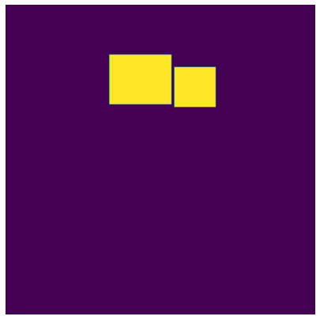

```python
#Print a sample image and Mask array
n = 30
fig = plt.figure(figsize = (15, 7.2))
ax = fig.add_subplot(1, 1, 1)
plt.axis('off')
_ = plt.imshow(masks[n])
```

**3. Mask detection model:**

**A) Design a face mask detection model.**

Add MobileNet as model with below parameter values

input_shape: IMAGE_HEIGHT, IMAGE_WIDTH, 3

include_top: False alpha: 1.0 weights:'imagenet' Add UNET architecture layers

```python
#Create face mask detection model.
def conv_block_simple(prevlayer, filters, prefix, strides=(1, 1)):
    conv = Conv2D(filters, (3, 3), padding = 'same', kernel_initializer = 'he_normal', strides = strides, name = prefix + '_conv')(prevlayer)
    conv = BatchNormalization(name = prefix + 'BatchNormalization')(conv)
    conv = Activation('relu', name = prefix + 'ActivationLayer')(conv)
    return conv

def create_model(trainable = True):
    model = MobileNet(input_shape = (IMAGE_HEIGHT, IMAGE_WIDTH, 3), include_top = False, alpha = ALPHA, weights = 'imagenet')
    for layer in model.layers:
        layer.trainable = trainable

    block1 = model.get_layer('conv_pw_13_relu').output
    block2 = model.get_layer('conv_pw_11_relu').output
    block3 = model.get_layer('conv_pw_5_relu').output
    block4 = model.get_layer('conv_pw_3_relu').output
    block5 = model.get_layer('conv_pw_1_relu').output

    up1 = Concatenate()([UpSampling2D()(block1), block2])
    conv6 = conv_block_simple(up1, 256, 'Conv_6_1')
    conv6 = conv_block_simple(conv6, 256, 'Conv_6_2')

    up2 = Concatenate()([UpSampling2D()(conv6), block3])
    conv7 = conv_block_simple(up2, 256, 'Conv_7_1')
    conv7 = conv_block_simple(conv7, 256, 'Conv_7_2')

    up3 = Concatenate()([UpSampling2D()(conv7), block4])
    conv8 = conv_block_simple(up3, 192, 'Conv_8_1')
    conv8 = conv_block_simple(conv8, 128, 'Conv_8_2')

    up4 = Concatenate()([UpSampling2D()(conv8), block5])
    conv9 = conv_block_simple(up4, 96, 'Conv_9_1')
    conv9 = conv_block_simple(conv9, 64, 'Conv_9_2')

    up5 = Concatenate()([UpSampling2D()(conv9), model.input])
    conv10 = conv_block_simple(up5, 48, 'Conv_10_1')
    conv10 = conv_block_simple(conv10, 32, 'Conv_10_2')
    conv10 = SpatialDropout2D(0.2)(conv10)

    x = Conv2D(1, (1, 1), activation = 'sigmoid')(conv10)
    x = Reshape((IMAGE_SIZE, IMAGE_SIZE))(x)
    return Model(inputs = model.input, outputs = x)
```

```python
#Invoke the create_model function
model = create_model(True)
model.summary()
```

```
Downloading data from https://storage.googleapis.com/tensorflow/keras-applications/mobilenet/mobilenet_1_0_224_tf_no_top.h5
Model: "model"
__________________________________________________________________________________________________
Layer (type)                    Output Shape         Param #     Connected to
==================================================================================================
input_1 (InputLayer)            [(None, 224, 224, 3) 0
__________________________________________________________________________________________________
conv1 (Conv2D)                  (None, 112, 112, 32) 864         input_1[0][0]
__________________________________________________________________________________________________
conv1_bn (BatchNormalization)   (None, 112, 112, 32) 128         conv1[0][0]
__________________________________________________________________________________________________
conv1_relu (ReLU)               (None, 112, 112, 32) 0           conv1_bn[0][0]
__________________________________________________________________________________________________
conv_dw_1 (DepthwiseConv2D)     (None, 112, 112, 32) 288         conv1_relu[0][0]
__________________________________________________________________________________________________
conv_dw_1_bn (BatchNormalizatio (None, 112, 112, 32) 128         conv_dw_1[0][0]
__________________________________________________________________________________________________
conv_dw_1_relu (ReLU)           (None, 112, 112, 32) 0           conv_dw_1_bn[0][0]
__________________________________________________________________________________________________
conv_pw_1 (Conv2D)              (None, 112, 112, 64) 2048        conv_dw_1_relu[0][0]
__________________________________________________________________________________________________
conv_pw_1_bn (BatchNormalizatio (None, 112, 112, 64) 256         conv_pw_1[0][0]
__________________________________________________________________________________________________
conv_pw_1_relu (ReLU)           (None, 112, 112, 64) 0           conv_pw_1_bn[0][0]
__________________________________________________________________________________________________
conv_pad_2 (ZeroPadding2D)      (None, 113, 113, 64) 0           conv_pw_1_relu[0][0]
__________________________________________________________________________________________________
conv_dw_2 (DepthwiseConv2D)     (None, 56, 56, 64)   576         conv_pad_2[0][0]
__________________________________________________________________________________________________
conv_dw_2_bn (BatchNormalizatio (None, 56, 56, 64)   256         conv_dw_2[0][0]
__________________________________________________________________________________________________
conv_dw_2_relu (ReLU)           (None, 56, 56, 64)   0           conv_dw_2_bn[0][0]
__________________________________________________________________________________________________
conv_pw_2 (Conv2D)              (None, 56, 56, 128)  8192        conv_dw_2_relu[0][0]
__________________________________________________________________________________________________
conv_pw_2_bn (BatchNormalizatio (None, 56, 56, 128)  512         conv_pw_2[0][0]
__________________________________________________________________________________________________
conv_pw_2_relu (ReLU)           (None, 56, 56, 128)  0           conv_pw_2_bn[0][0]
__________________________________________________________________________________________________
conv_dw_3 (DepthwiseConv2D)     (None, 56, 56, 128)  1152        conv_pw_2_relu[0][0]
```

[output cut: 217 more lines]

```
__________________________________________________________________________________________________
Conv_10_2BatchNormalization (Ba (None, 224, 224, 32) 128         Conv_10_2_conv[0][0]
__________________________________________________________________________________________________
Conv_10_2ActivationLayer (Activ (None, 224, 224, 32) 0           Conv_10_2BatchNormalization[0][0]
__________________________________________________________________________________________________
spatial_dropout2d (SpatialDropo (None, 224, 224, 32) 0           Conv_10_2ActivationLayer[0][0]
__________________________________________________________________________________________________
conv2d (Conv2D)                 (None, 224, 224, 1)  33          spatial_dropout2d[0][0]
__________________________________________________________________________________________________
reshape (Reshape)               (None, 224, 224)     0           conv2d[0][0]
==================================================================================================
Total params: 10,283,745
Trainable params: 10,258,689
Non-trainable params: 25,056
__________________________________________________________________________________________________
```

**B) Design your own Dice Coefficient and Loss function.**

```python
#Function to calculate dice coefficient
def dice_coefficient(y_true, y_pred):
    numerator = 2 * tf.reduce_sum(y_true * y_pred)
    denominator = tf.reduce_sum(y_true + y_pred)

    return numerator / (denominator + tf.keras.backend.epsilon())
```

```python
#Define loss function
def loss(y_true, y_pred):
    return binary_crossentropy(y_true, y_pred) - log(dice_coefficient(y_true, y_pred) + epsilon())
```

**C) Train, tune and test the model.**

Complie the model using Parameters like loss, Adam optimizer and metrics as dice_coefficient function.

```python
adam = Adam(lr = 1e-4, beta_1 = 0.9, beta_2 = 0.999, epsilon = None, decay = 0.0, amsgrad = False)
model.compile(loss = loss, optimizer = adam, metrics = [dice_coefficient])
```

```python
#Define checkpoint and earlystopping
checkpoint = ModelCheckpoint('model_{loss:.2f}.h5', monitor = 'loss', verbose = 1, save_best_only = True, save_weights_only = True, mode = 'min', period = 1)
stop = EarlyStopping(monitor = 'loss', patience = 5, mode = 'min')
reduce_lr = ReduceLROnPlateau(monitor = 'loss', factor = 0.2, patience = 5, min_lr = 1e-6, verbose = 1, mode = 'min')
```

```
WARNING:tensorflow:`period` argument is deprecated. Please use `save_freq` to specify the frequency in number of batches seen.
```

```python
#Fit the model using epochs and batch_size as 1.
#callbacks: checkpoint, reduce_lr, stop
#Spliting data into training and testing set
#training set : 70% and testing set: 30%

X_train, X_test, y_train, y_test = train_test_split(X, masks, test_size = 0.3, random_state = 50, shuffle = False)
X_train.shape, X_test.shape, y_train.shape, y_test.shape
```

```
((286, 224, 224, 3), (123, 224, 224, 3), (286, 224, 224), (123, 224, 224))
```

```python
#Create Validation data set
#split test data into 50% test, 50% validation data
from sklearn.model_selection import train_test_split
X_test, X_valid, y_test, y_valid = train_test_split(X_test,y_test, test_size = 0.5, random_state=50,shuffle = False)
X_test.shape, X_valid.shape, y_test.shape, y_valid.shape
```

[output not shown]

```python
model.fit(X_train, y_train, epochs = 20, batch_size = 1, callbacks = [checkpoint, reduce_lr, stop], validation_data = (X_valid, y_valid))
```

```
Epoch 00001: loss improved from inf to 1.52825, saving model to model_1.53.h5

Epoch 00002: loss improved from 1.52825 to 1.08523, saving model to model_1.09.h5

Epoch 00003: loss improved from 1.08523 to 0.86137, saving model to model_0.86.h5

Epoch 00004: loss improved from 0.86137 to 0.69132, saving model to model_0.69.h5

Epoch 00005: loss improved from 0.69132 to 0.58460, saving model to model_0.58.h5

Epoch 00006: loss improved from 0.58460 to 0.52542, saving model to model_0.53.h5

Epoch 00007: loss improved from 0.52542 to 0.43407, saving model to model_0.43.h5

Epoch 00008: loss improved from 0.43407 to 0.37657, saving model to model_0.38.h5

Epoch 00009: loss improved from 0.37657 to 0.33171, saving model to model_0.33.h5

Epoch 00010: loss improved from 0.33171 to 0.31182, saving model to model_0.31.h5

Epoch 00011: loss improved from 0.31182 to 0.28852, saving model to model_0.29.h5

Epoch 00012: loss improved from 0.28852 to 0.25626, saving model to model_0.26.h5

Epoch 00013: loss improved from 0.25626 to 0.23221, saving model to model_0.23.h5

Epoch 00014: loss improved from 0.23221 to 0.21303, saving model to model_0.21.h5

Epoch 00015: loss improved from 0.21303 to 0.20655, saving model to model_0.21.h5

Epoch 00016: loss improved from 0.20655 to 0.19695, saving model to model_0.20.h5

Epoch 00017: loss improved from 0.19695 to 0.17657, saving model to model_0.18.h5

Epoch 00018: loss improved from 0.17657 to 0.17247, saving model to model_0.17.h5

Epoch 00019: loss improved from 0.17247 to 0.16117, saving model to model_0.16.h5

Epoch 00020: loss improved from 0.16117 to 0.15298, saving model to model_0.15.h5
```

```
<tensorflow.python.keras.callbacks.History at 0x7f119e389850>
```

```python
model.evaluate(X_valid, y_valid, verbose = 1)
```

```
[0.7326334118843079, 0.6759249567985535]
```

**3.D Evaluate the model using testing data.**

```python
#Evaluate the model using testing data.
model.evaluate(X_test, y_test, verbose = 1)
```

```
[0.8335554003715515, 0.6447272300720215]
```

**4. Use the “Prediction image” as an input to your Designed model and display the output of the image.**

# Let's use pretrained weights

```python
# Load previous model weight
WEIGHTS_FILE = "model_0.43.h5"
learned_model = create_model()
learned_model.load_weights(WEIGHTS_FILE)
```

[output not shown]

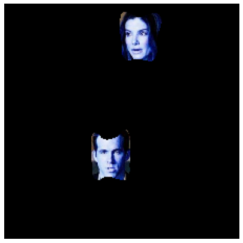

```python
import matplotlib.pyplot as plt
filename = "Part 1Test Data - Prediction Image.jpeg"

unscaled = cv2.imread(filename)
image = cv2.resize(unscaled, (IMAGE_WIDTH, IMAGE_HEIGHT))
feat_scaled = preprocess_input(np.array(image, dtype=np.float32))

pred_mask = cv2.resize(1.0*(learned_model.predict(x=np.array([feat_scaled]))[0] > 0.5), (IMAGE_WIDTH,IMAGE_HEIGHT))

image2 = image
image2[:,:,0] = pred_mask*image[:,:,0]
image2[:,:,1] = pred_mask*image[:,:,1]
image2[:,:,2] = pred_mask*image[:,:,2]

out_image = image2
fig = plt.figure(figsize = (15, 7.2))
ax = fig.add_subplot(1, 1, 1)
plt.axis('off')
plt.imshow(out_image)
```

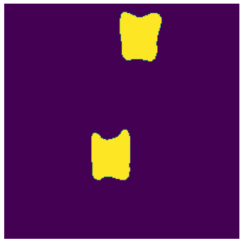

```python
fig = plt.figure(figsize = (15, 7.2))
ax = fig.add_subplot(1, 1, 1)
plt.axis('off')
plt.imshow(pred_mask, alpha = 1)
```

[figure not shown]

```python
fig = plt.figure(figsize = (15, 7.2))
ax = fig.add_subplot(1, 1, 1)
plt.axis('off')
plt.imshow(unscaled)
plt.savefig('image.jpg', bbox_inches = 'tight', pad_inches = 0)
```

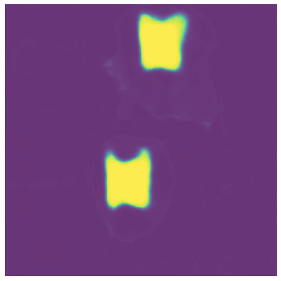

```python
y_pred= learned_model.predict(x=np.array([feat_scaled]))
fig = plt.figure(figsize = (15, 7.2))
ax = fig.add_subplot(1, 1, 1)
plt.axis('off')
plt.imshow(y_pred[0], alpha = 0.8)
plt.savefig('mask.jpg', bbox_inches = 'tight', pad_inches = 0)
```

[figure not shown]

```python
from google.colab.patches import cv2_imshow
img = cv2.imread('image.jpg', 1)
mask = cv2.imread('mask.jpg', 1)
img = cv2.add(img, mask)
cv2_imshow(img)
```

PART **TWO**

```python
import os; os.chdir('/content/drive/MyDrive/AIML/Projects/Face recognition Project')
```

```python
#Import Packages
import pandas as pd, numpy as np, matplotlib.pyplot as plt
from tensorflow.keras.applications.mobilenet import preprocess_input
from matplotlib import pyplot
%matplotlib inline
import cv2
from PIL import Image
import sys
```

```python
import numpy as np
import cv2
import random
face_cascade = cv2.CascadeClassifier(cv2.data.haarcascades + 'haarcascade_frontalface_default.xml')
eye_cascade = cv2.CascadeClassifier(cv2.data.haarcascades + 'haarcascade_eye.xml')
filename ='Part 1Test Data - Prediction Image.jpeg'
img = cv2.imread(filename)
gray = cv2.cvtColor(img, cv2.COLOR_BGR2GRAY)
faces = face_cascade.detectMultiScale(gray, 1.3, 1)
i=0
for (x,y,w,h) in faces:
    cv2.rectangle(img,(x,y),(x+w,y+h),(255,0,0),2)
    roi_gray = gray[y:y+h, x:x+w]
    roi_color = img[y:y+h, x:x+w]
    i=i+1

BBox ={'X': [x],'Y': [y],'W' :[w],'H':[h],'Faces':[i],'file':[filename]}
BBox_df = pd.DataFrame(BBox)
BBox_df.to_csv('BBox_df.csv', index=False)
print(BBox_df.head())
cv2.imwrite('bb_testdata.png',img)
```

```
     X    Y   W   H  Faces                                     file
0  186  284  81  81      2  Part 1Test Data - Prediction Image.jpeg
```

```
True
```

[figure not shown]

```python
from google.colab.patches import cv2_imshow
img = cv2.imread('bb_testdata.png', 1)
cv2_imshow(img)
```

Challenges - I've faced some difficulty to import numpy file to draw bounding boxes for all images. Hereby, I've imported test.jpeg image to find out the Bounding boxes coordinates and number of faces detected along with file name.

*PART THREE*

```python
%tensorflow_version 2.x
```

```python
import os; os.chdir('/content/drive/MyDrive/AIML/Projects/Face recognition Project/Part 3 - Aligned Face Dataset from Pinterest')
```

```python
%ls
```

```
'Part 3 - vgg_face_weights.h5'   PINS/
```

```python
# Imports
import pandas as pd, numpy as np, matplotlib.pyplot as plt, sklearn, re, random
import matplotlib.gridspec as gridspec
from tqdm.notebook import tqdm
import tensorflow, cv2
%matplotlib inline

# Model
from tensorflow.keras.layers import ZeroPadding2D, Convolution2D, MaxPooling2D, Dropout, Flatten, Activation
from tensorflow.keras.models import Sequential, Model
from sklearn.svm import SVC

# Encode, standardize and PCA
from sklearn.metrics import classification_report, confusion_matrix, accuracy_score
from sklearn.model_selection import RandomizedSearchCV, GridSearchCV
from sklearn.preprocessing import LabelEncoder, StandardScaler
from sklearn.decomposition import PCA

# Set random_state
random_state = 2020

# Suppress warnings, if any
import warnings; warnings.filterwarnings('ignore')

# Print versions
print(f'Pandas version: {pd.__version__}')
print(f'Numpy version: {np.__version__}')
print(f'Scikit-learn version: {sklearn.__version__}')
print(f'Tensorflow version: {tensorflow.__version__}')
print(f'CV version: {cv2.__version__}')
```

```
Pandas version: 1.1.5
Numpy version: 1.19.5
Scikit-learn version: 0.22.2.post1
Tensorflow version: 2.4.1
CV version: 4.1.2
```

**1-Load the dataset and create the metadata.**

```python
#Function to load images

class IdentityMetadata():
    def __init__(self, base, name, file):
        # print(base, name, file)
        # dataset base directory
        self.base = base
        # identity name
        self.name = name
        # image file name
        self.file = file

    def __repr__(self):
        return self.image_path()

    def image_path(self):
        return os.path.join(self.base, self.name, self.file)

def load_metadata(path):
    metadata = []
    exts = []
    for i in os.listdir(path):
        for f in os.listdir(os.path.join(path, i)):
            # Check file extension. Allow only jpg/jpeg' files.
            ext = os.path.splitext(f)[1]
            if ext == '.jpg' or ext == '.jpeg':
                metadata.append(IdentityMetadata(path, i, f))
                exts.append(ext)
    return np.array(metadata), exts

metadata, exts = load_metadata('PINS')
labels = np.array([meta.name for meta in metadata])
```

```python
#Define a function to load image from the metadata

def load_image(path):
    img = cv2.imread(path, 1)
    # OpenCV loads images with color channels
    # in BGR order. So we need to reverse them
    return img[...,::-1]
```

**2)Check some samples of metadata.**

```python
#Load one image using the function "load_image"
n = np.random.randint(1, len(metadata))
img_path = metadata[n].image_path()
img = load_image(img_path)
```

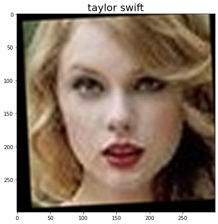

```python
fig = plt.figure(figsize = (15, 7.2))
ax = fig.add_subplot(1, 1, 1)
title = labels[n].split('_')[1]
ax.set_title(title, fontsize = 20)
_ = plt.imshow(img)
```

```python
import numpy as np
#Load one image using the function "load_image"
n = np.random.randint(1, len(metadata))
img_path = metadata[n].image_path()
img = load_image(img_path)
```

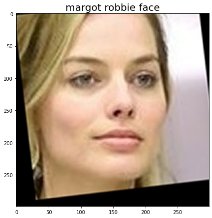

```python
fig = plt.figure(figsize = (15, 7.2))
ax = fig.add_subplot(1, 1, 1)
title = labels[n].split('_')[1]
ax.set_title(title, fontsize = 20)
_ = plt.imshow(img)
```

**3) Load the pre-trained model and weights.**

```python
#VGG Face model
def vgg_face():
    model = Sequential()
    model.add(ZeroPadding2D((1, 1), input_shape = (224, 224, 3)))
    model.add(Convolution2D(64, (3, 3), activation = 'relu'))
    model.add(ZeroPadding2D((1, 1)))
    model.add(Convolution2D(64, (3, 3), activation = 'relu'))
    model.add(MaxPooling2D((2, 2), strides = (2, 2)))

    model.add(ZeroPadding2D((1, 1)))
    model.add(Convolution2D(128, (3, 3), activation = 'relu'))
    model.add(ZeroPadding2D((1, 1)))
    model.add(Convolution2D(128, (3, 3), activation = 'relu'))
    model.add(MaxPooling2D((2, 2), strides = (2, 2)))

    model.add(ZeroPadding2D((1, 1)))
    model.add(Convolution2D(256, (3, 3), activation = 'relu'))
    model.add(ZeroPadding2D((1, 1)))
    model.add(Convolution2D(256, (3, 3), activation = 'relu'))
    model.add(ZeroPadding2D((1, 1)))
    model.add(Convolution2D(256, (3, 3), activation = 'relu'))
    model.add(MaxPooling2D((2, 2), strides = (2, 2)))

    model.add(ZeroPadding2D((1, 1)))
    model.add(Convolution2D(512, (3, 3), activation = 'relu'))
    model.add(ZeroPadding2D((1, 1)))
    model.add(Convolution2D(512, (3, 3), activation = 'relu'))
    model.add(ZeroPadding2D((1, 1)))
    model.add(Convolution2D(512, (3, 3), activation = 'relu'))
    model.add(MaxPooling2D((2, 2), strides =(2, 2)))

    model.add(ZeroPadding2D((1, 1)))
    model.add(Convolution2D(512, (3, 3), activation = 'relu'))
    model.add(ZeroPadding2D((1, 1)))
    model.add(Convolution2D(512, (3, 3), activation = 'relu'))
    model.add(ZeroPadding2D((1, 1)))
    model.add(Convolution2D(512, (3, 3), activation = 'relu'))
    model.add(MaxPooling2D((2, 2), strides=(2, 2)))

    model.add(Convolution2D(4096, (7, 7), activation = 'relu'))
    model.add(Dropout(0.5))
    model.add(Convolution2D(4096, (1, 1), activation = 'relu'))
    model.add(Dropout(0.5))
    model.add(Convolution2D(2622, (1, 1)))
    model.add(Flatten())
    model.add(Activation('softmax'))
    return model
```

```python
#Load the model
model = vgg_face()
model.load_weights('Part 3 - vgg_face_weights.h5')
print(model.summary())
```

```
Model: "sequential_7"
_________________________________________________________________
Layer (type)                 Output Shape              Param #
=================================================================
zero_padding2d_91 (ZeroPaddi (None, 226, 226, 3)       0
_________________________________________________________________
conv2d_112 (Conv2D)          (None, 224, 224, 64)      1792
_________________________________________________________________
zero_padding2d_92 (ZeroPaddi (None, 226, 226, 64)      0
_________________________________________________________________
conv2d_113 (Conv2D)          (None, 224, 224, 64)      36928
_________________________________________________________________
max_pooling2d_35 (MaxPooling (None, 112, 112, 64)      0
_________________________________________________________________
zero_padding2d_93 (ZeroPaddi (None, 114, 114, 64)      0
_________________________________________________________________
conv2d_114 (Conv2D)          (None, 112, 112, 128)     73856
_________________________________________________________________
zero_padding2d_94 (ZeroPaddi (None, 114, 114, 128)     0
_________________________________________________________________
conv2d_115 (Conv2D)          (None, 112, 112, 128)     147584
_________________________________________________________________
max_pooling2d_36 (MaxPooling (None, 56, 56, 128)       0
_________________________________________________________________
zero_padding2d_95 (ZeroPaddi (None, 58, 58, 128)       0
_________________________________________________________________
conv2d_116 (Conv2D)          (None, 56, 56, 256)       295168
_________________________________________________________________
zero_padding2d_96 (ZeroPaddi (None, 58, 58, 256)       0
_________________________________________________________________
conv2d_117 (Conv2D)          (None, 56, 56, 256)       590080
_________________________________________________________________
zero_padding2d_97 (ZeroPaddi (None, 58, 58, 256)       0
_________________________________________________________________
conv2d_118 (Conv2D)          (None, 56, 56, 256)       590080
_________________________________________________________________
max_pooling2d_37 (MaxPooling (None, 28, 28, 256)       0
_________________________________________________________________
zero_padding2d_98 (ZeroPaddi (None, 30, 30, 256)       0
_________________________________________________________________
```

[output cut: 30 more lines]

```
conv2d_126 (Conv2D)          (None, 1, 1, 4096)        16781312
_________________________________________________________________
dropout_15 (Dropout)         (None, 1, 1, 4096)        0
_________________________________________________________________
conv2d_127 (Conv2D)          (None, 1, 1, 2622)        10742334
_________________________________________________________________
flatten_7 (Flatten)          (None, 2622)              0
_________________________________________________________________
activation_7 (Activation)    (None, 2622)              0
=================================================================
Total params: 145,002,878
Trainable params: 145,002,878
Non-trainable params: 0
_________________________________________________________________
None
```

```python
vgg_face_descriptor = Model(inputs = model.layers[0].input, outputs = model.layers[-2].output)
```

**4) Generate Embedding vectors for each face in the dataset.**

```python
# Get embedding vector for first image in the metadata using the pre-trained model

img_path = metadata[0].image_path()
img = load_image(img_path)

# Normalising pixel values from [0-255] to [0-1]: scale RGB values to interval [0, 1]
img = (img / 255.).astype(np.float32)

img = cv2.resize(img, dsize = (224, 224))
print(img.shape)

# Obtain embedding vector for an image
# Get the embedding vector for the above image using vgg_face_descriptor model and print the shape
embedding_vector = vgg_face_descriptor.predict(np.expand_dims(img, axis = 0))[0]
print(embedding_vector.shape)
```

```
(224, 224, 3)
(2622,)
```

```python
embeddings = []
embeddings = np.zeros((metadata.shape[0], 2622))
for i, meta in tqdm(enumerate(metadata)):
  try:
    image = load_image(str(meta))
    image = (image/255.).astype(np.float32)
    image = cv2.resize(image, (224, 224))
    embeddings[i] = vgg_face_descriptor.predict(np.expand_dims(image, axis = 0))[0]
  except:
    embeddings[i] = np.zeros(2622)
```

**5) Build distance metrics for identifying the distance between two given images.**

Squared l2 distance between 2 points (x1, y1) and (x2, y2) = (x1-x2)^2 + (y1-y2)^2

```python
def distance(emb1, emb2):
    return np.sum(np.square(emb1 - emb2))
```

```python
#Plot images and get distance between the pairs given below

def show_pair(idx1, idx2):
    plt.figure(figsize = (8, 3))
    plt.suptitle(f'Distance = {distance(embeddings[idx1], embeddings[idx2]):.2f}')
    plt.subplot(121)
    plt.imshow(load_image(metadata[idx1].image_path()))
    plt.subplot(122)
    plt.imshow(load_image(metadata[idx2].image_path()))
```

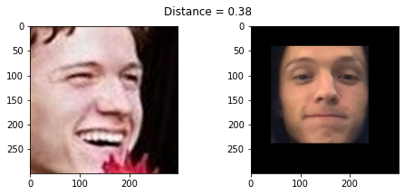

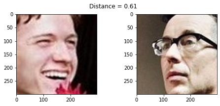

```python
show_pair(10, 11)
show_pair(10, 150)
```

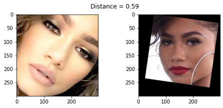

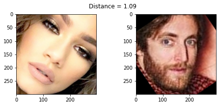

```python
show_pair(500, 502)
show_pair(500, 600)
```

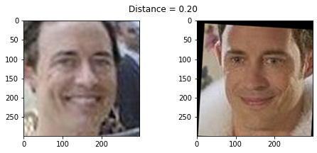

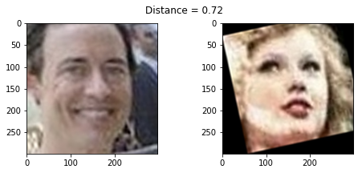

```python
show_pair(200, 201)
show_pair(200, 400)
```

*Create train and test sets*

```python
#Create X_train, X_test and y_train, y_test
#train_idx & test_idx to seperate out training features and labels
train_idx = np.arange(metadata.shape[0]) % 9 != 0
test_idx = np.arange(metadata.shape[0]) % 9 == 0

# Features
X_train = np.array(embeddings)[train_idx]
X_test = np.array(embeddings)[test_idx]

# Labels
y_train = np.array([meta.name for meta in metadata[train_idx]])
y_test = np.array([meta.name for meta in metadata[test_idx]])

display(X_train.shape, X_test.shape, y_train.shape, y_test.shape)
```

```
(9591, 2622)
```

```
(1199, 2622)
```

```
(9591,)
```

```
(1199,)
```

```python
#Encode the Labels
en = LabelEncoder()
y_train = en.fit_transform(y_train)
y_test = en.transform(y_test)
```

```python
# Standarize features using StandardScaler
sc = StandardScaler()
X_train_sc = sc.fit_transform(X_train)
X_test_sc = sc.transform(X_test)
```

**6) Use PCA for dimensionality reduction.**

```python
#Reduce feature dimensions using Principal Component Analysis

# Covariance matrix
cov_matrix = np.cov(X_train_sc.T)

# Eigen values and vector
eig_vals, eig_vecs = np.linalg.eig(cov_matrix)

# Cumulative variance explained
tot = sum(eig_vals)
var_exp = [(i /tot) * 100 for i in sorted(eig_vals, reverse = True)]
cum_var_exp = np.cumsum(var_exp)

print('Cumulative Variance Explained', cum_var_exp)
```

```
Cumulative Variance Explained [ 13.56799263  18.93701699  22.90031592 ...  99.99999983  99.99999999
 100.        ]
```

```python
# Retrieve index where cumulative variance explained > threshold
thres = 95
res = list(filter(lambda i: i > thres, cum_var_exp))[0]
index = (cum_var_exp.tolist().index(res))
print(f'Index of element just greater than {thres}: {str(index)}')
```

```
Index of element just greater than 95: 347
```

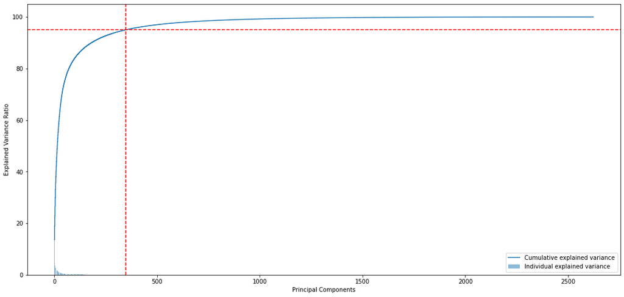

```python
# Plotting PCA graph
plt.figure(figsize = (15 , 7.2))
plt.bar(range(1, eig_vals.size + 1), var_exp, alpha = 0.5, align = 'center', label = 'Individual explained variance')
plt.step(range(1, eig_vals.size + 1), cum_var_exp, where = 'mid', label = 'Cumulative explained variance')
plt.axhline(y = thres, color = 'r', linestyle = '--')
plt.axvline(x = index, color = 'r', linestyle = '--')
plt.ylabel('Explained Variance Ratio')
plt.xlabel('Principal Components')
plt.legend(loc = 'best')
plt.tight_layout()
plt.show()
```

```python
# Reducing the dimensions
pca = PCA(n_components = index, random_state = random_state, svd_solver = 'full', whiten = True)
pca.fit(X_train_sc)
X_train_pca = pca.transform(X_train_sc)
X_test_pca = pca.transform(X_test_sc)
display(X_train_pca.shape, X_test_pca.shape)
```

```
(9591, 347)
```

```
(1199, 347)
```

**7) Build an SVM classifier to map each image to its right person.**

```python
#Use SVM classifier to predict each image to its right person.
svc_pca = SVC(C = 1, gamma = 0.001, kernel = 'rbf', class_weight = 'balanced', random_state = random_state)
svc_pca.fit(X_train_pca, y_train)
print('SVC accuracy for train set: {0:.3f}'.format(svc_pca.score(X_train_pca, y_train)))
```

```
SVC accuracy for train set: 0.995
```

```python
y_pred = svc_pca.predict(X_test_pca)

# Print Accuracy Score
print('Accuracy Score: {}'.format(accuracy_score(y_test, y_pred).round(3)))
```

```
Accuracy Score: 0.971
```

```python
names = [name.split('_')[1].title().strip() for name in labels]

# Classification Report
print('Classification Report: \n{}'.format(classification_report(y_test, y_pred, target_names = np.unique(names))))
```

```
Classification Report:
                          precision    recall  f1-score   support

              Aaron Paul       1.00      0.89      0.94         9
      Alexandra Daddario       0.91      1.00      0.95        10
            Alvaro Morte       0.93      1.00      0.96        13
Alycia Debnam Carey Face       1.00      1.00      1.00        13
             Amanda Crew       1.00      0.88      0.93         8
          Amaury Nolasco       1.00      1.00      1.00         9
        Amber Heard Face       1.00      1.00      1.00         8
               Anna Gunn       1.00      1.00      1.00        15
           Anne Hathaway       1.00      0.92      0.96        13
     Barbara Palvin Face       1.00      1.00      1.00         9
      Bellamy Blake Face       1.00      0.86      0.92        14
    Benedict Cumberbatch       1.00      1.00      1.00        12
            Betsy Brandt       1.00      1.00      1.00        10
              Bill Gates       0.83      1.00      0.91        10
        Brenton Thwaites       1.00      1.00      1.00        15
             Brie Larson       1.00      1.00      1.00        15
            Brit Marling       0.92      1.00      0.96        12
          Bryan Cranston       0.93      1.00      0.97        14
              Caity Lotz       1.00      1.00      1.00        12
        Cameron Monaghan       1.00      1.00      1.00        14
   Chadwick Boseman Face       1.00      1.00      1.00        17
          Chance Perdomo       0.82      1.00      0.90         9
             Chris Evans       1.00      1.00      1.00        14
             Chris Pratt       1.00      1.00      1.00        14
          Cobie Smulders       1.00      0.86      0.92        14
      Danielle Panabaker       1.00      1.00      1.00        15
             Dave Franco       1.00      1.00      1.00        13
            David Mazouz       1.00      1.00      1.00        11
         Dominic Purcell       1.00      1.00      1.00        12
                   Drake       1.00      0.71      0.83         7
           Dua Lipa Face       1.00      1.00      1.00        12
          Dwayne Johnson       1.00      1.00      1.00        11
            Eliza Taylor       1.00      1.00      1.00        13
    Elizabeth Olsen Face       1.00      1.00      1.00        10
               Elon Musk       1.00      1.00      1.00        16
           Emilia Clarke       1.00      1.00      1.00        13
     Emily Bett Rickards       1.00      1.00      1.00         6
```

[output cut: 52 more lines]

```
           Sundar Pichai       1.00      0.89      0.94         9
          Tati Gabrielle       1.00      1.00      1.00         9
            Taylor Swift       1.00      1.00      1.00        13
      Thomas Middleditch       1.00      0.92      0.96        12
            Tom Cavanagh       1.00      1.00      1.00         9
        Tom Holland Face       0.82      0.90      0.86        10
          Ursula Corbero       1.00      1.00      1.00         6
        Wentworth Miller       0.88      1.00      0.93         7
           Willa Holland       1.00      1.00      1.00        11
        William Fichtner       0.93      1.00      0.97        14
                 Zendaya       1.00      0.92      0.96        12

                accuracy                           0.97      1199
               macro avg       0.97      0.97      0.97      1199
            weighted avg       0.98      0.97      0.97      1199
```

**8)Predict using the SVM model.**

```python
def sample_img_plot(sample_idx):
  # Load image for sample_idx from test data
  sample_img = load_image(metadata[test_idx][sample_idx].image_path())
  # Get actual name
  actual_name = metadata[test_idx][sample_idx].name.split('_')[-1].title().strip()
  # Normalizing pixel values
  sample_img = (sample_img/255.).astype(np.float32)
  # Resize
  sample_img = cv2.resize(sample_img, (224, 224))

  # Obtain embedding vector for sample image
  embedding = vgg_face_descriptor.predict(np.expand_dims(sample_img, axis = 0))[0]
  # Scaled the vector and reshape
  embedding_scaled = sc.transform(embedding.reshape(1, -1))
  # Predict
  sample_pred = svc_pca.predict(pca.transform(embedding_scaled))
  # Transform back
  pred_name = en.inverse_transform(sample_pred)[0].split('_')[-1].title().strip()
  return sample_img, actual_name, pred_name
```

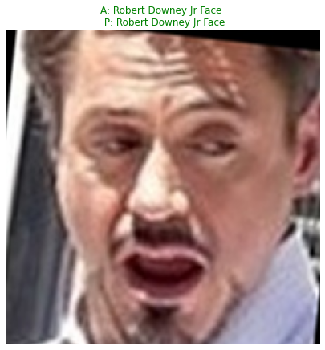

```python
# Plot for 25th image in test data
sample_img, actual_name, pred_name = sample_img_plot(250)
fig = plt.figure(figsize = (15, 7.2))
plt.axis('off')
plt.imshow(sample_img)
plt.title(f"A: {actual_name} \n P: {pred_name}", color = 'green' if actual_name == pred_name else 'red')
plt.show()
```

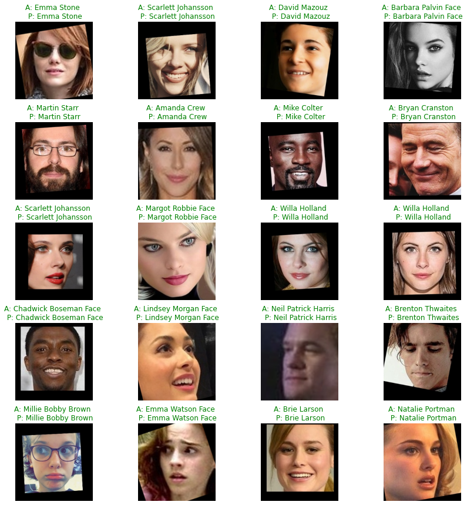

```python
# Random 20 sample images from test data
plt.figure(figsize = (15, 15))
gs1 = gridspec.GridSpec(5, 4)
gs1.update(wspace = 0, hspace = 0.3)

for i in range(20):
    ax1 = plt.subplot(gs1[i])
    plt.axis('on')
    ax1.set_xticklabels([])
    ax1.set_yticklabels([])
    ax1.set_aspect('equal')

    sample_img, actual_name, pred_name = sample_img_plot(random.randint(1, 1197))

    plt.axis('off')
    plt.imshow(sample_img)

    plt.title(f"A: {actual_name} \n P: {pred_name}", color = 'green' if actual_name == pred_name else 'red')
plt.show()
```

**Part Four** - Imputing Bounding boxes on Video files

```python
import os; os.chdir('/content/drive/MyDrive/AIML/Projects/Face recognition Project/Part 4 Video/Video')
```

```python
import re
import cv2 # opencv library
import numpy as np
from os.path import isfile, join
import matplotlib.pyplot as plt
```

```python
col_images=[]
# kernel for image dilation
kernel = np.ones((4,4),np.uint8)

# font style
font = cv2.FONT_HERSHEY_SIMPLEX

# directory to save the ouput frames
pathIn = "contour_frames_5/"

for i in range(len(col_images)-1):

    # frame differencing
    grayA = cv2.cvtColor(col_images[i], cv2.COLOR_BGR2GRAY)
    grayB = cv2.cvtColor(col_images[i+1], cv2.COLOR_BGR2GRAY)
    diff_image = cv2.absdiff(grayB, grayA)

    # image thresholding
    ret, thresh = cv2.threshold(diff_image, 30, 255, cv2.THRESH_BINARY)

    # image dilation
    dilated = cv2.dilate(thresh,kernel,iterations = 1)

    # find contours
    contours, hierarchy = cv2.findContours(dilated.copy(), cv2.RETR_TREE,cv2.CHAIN_APPROX_NONE)

    # shortlist contours appearing in the detection zone
    valid_cntrs = []
    for cntr in contours:
        x,y,w,h = cv2.boundingRect(cntr)
        if (x <= 200) & (y >= 80) & (cv2.contourArea(cntr) >= 25):
            if (y >= 90) & (cv2.contourArea(cntr) < 40):
                break
            valid_cntrs.append(cntr)

    # add contours to original frames
    dmy = col_images[i].copy()
    cv2.drawContours(dmy, valid_cntrs, -1, (127,200,0), 2)

    cv2.putText(dmy, "vehicles detected: " + str(len(valid_cntrs)), (55, 15), font, 0.6, (0, 180, 0), 2)
    cv2.line(dmy, (0, 80),(256,80),(100, 255, 255))
    cv2.imwrite(pathIn+str(i)+'.png',dmy)
```

```python
# specify video name
pathOut = 'video1.mp4'

# specify frames per second
fps = 14.0
```

```python
frame_array = []
files = [f for f in os.listdir(pathIn) if isfile(join(pathIn, f))]
```

```python
files.sort(key=lambda f: int(re.sub('\D', '', f)))

for i in range(len(files)):
    filename=pathIn + files[i]

    #read frames
    img = cv2.imread(filename)
    height, width, layers = img.shape
    size = (width,height)

    #inserting the frames into an image array
    frame_array.append(img)
```

```python
out = cv2.VideoWriter(pathOut,cv2.VideoWriter_fourcc(*'DIVX'), fps, size)

for i in range(len(frame_array)):
    # writing to a image array
    out.write(frame_array[i])

out.release()
```